# Data_visualization_HW_1

# 5. Model Diagnostics

## 5.1. Residual Analysis

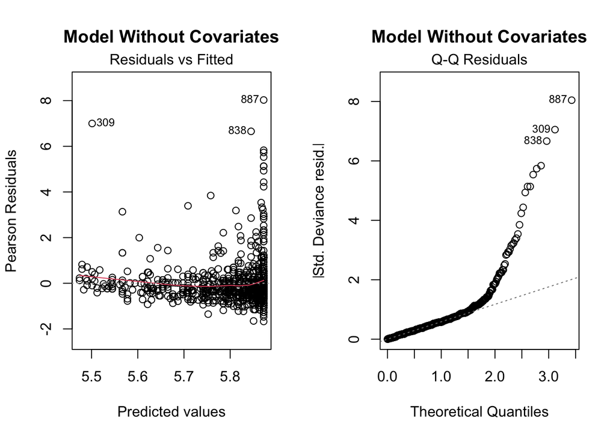

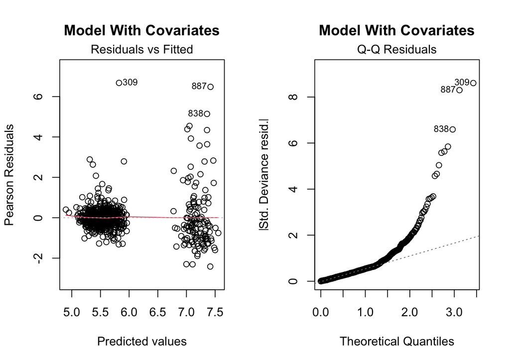

[output not shown]

**Model without covariates:** *Residuals vs. Fitted*

The plot shows some clear patterns (curvature and fanning out at higher fitted values). This suggests non-linearity and heteroscedasticity in the model. Outliers are evident (e.g., points labeled 838, 309, 887).

*Q-Q Plot*

The residuals deviate significantly from the theoretical quantiles, especially at the tails, indicating non-normality.

**Model with covariates:** *Residuals vs. Fitted*

*Q-Q Plot*

The residuals deviate from the diagonal line, particularly at the tails, indicating non-normality.

*Suggested Transformations:* Log Transformation of the HbA1c, removing outliers, Weighted Least Squares (due to heteroscedasticity).